# Customer Behaviour Segmentation

This project explores customer behavior segmentation using three distinct clustering models; K-Means, DBSCAN and Hierarchical Clustering in R-studio applied to the Mall Customer Dataset. The primary objective is to understand and categorize customer behavior based on their spending patterns and demographic attributes and suggest the best model for customer segmentation and recommendations. .

The dataset, containing information such as customer age, annual income, and spending score, undergoes preprocessing steps like scaling or normalization. Subsequently, DBSCAN, Hierarchical Clustering, and K-Means algorithms are applied to cluster customers into distinct segments.

Evaluation metrics and visualizations, including scatter plots, pair plots, and cluster comparison charts, are utilized to assess the quality and effectiveness of the generated clusters. The study compares the performance of these models in identifying coherent customer segments, highlighting their strengths and weaknesses in handling varying shapes and sizes of clusters, noise, and outliers within the dataset.

This investigation aims to provide insights into the diverse approaches of customer segmentation using different clustering methodologies, offering guidance on the most suitable model for extracting meaningful and actionable customer behavior patterns from the Mall Customer Dataset.

```r
# Load dataset
customer_data <- read.csv("C:/Users/LENOVO/Desktop/ThinkPacificProject/Mall_Customers.csv")
```

```r
#Rename some column names
customer_data <- rename(customer_data, Annual_Income=Annual.Income..k..,
                   Spending_Score=Spending.Score..1.100., Gender=Genre)
```

```r
#View customer
View(customer_data)
```

```r
# Convert heart_data to a data frame
customer_df <- as.data.frame(customer_data)
```

```r
# make a copy of the df
customer_df_km <- customer_df
```

```r
# view the head
head(customer_df)
```

|  | CustomerID | Gender | Age | Annual_Income | Spending_Score |
| --- | --- | --- | --- | --- | --- |
| 1 | 1 | Male | 19 | 15 | 39 |
| 2 | 2 | Male | 21 | 15 | 81 |
| 3 | 3 | Female | 20 | 16 | 6 |
| 4 | 4 | Female | 23 | 16 | 77 |
| 5 | 5 | Female | 31 | 17 | 40 |
| 6 | 6 | Female | 22 | 17 | 76 |

```r
#dimensions of the data
dim(customer_df)
```

```
[1] 200   5
```

```r
#data structure
str(customer_df)
```

```
'data.frame':   200 obs. of  5 variables:
 $ CustomerID    : int  1 2 3 4 5 6 7 8 9 10 ...
 $ Gender        : chr  "Male" "Male" "Female" "Female" ...
 $ Age           : int  19 21 20 23 31 22 35 23 64 30 ...
 $ Annual_Income : int  15 15 16 16 17 17 18 18 19 19 ...
 $ Spending_Score: int  39 81 6 77 40 76 6 94 3 72 ...
```

```r
# list types for each attribute
sapply(customer_df, class)
```

```
    CustomerID         Gender            Age  Annual_Income Spending_Score
     "integer"    "character"      "integer"      "integer"      "integer"
```

```r
#data summary
summary(customer_df)
```

```
   CustomerID        Gender               Age        Annual_Income    Spending_Score
 Min.   :  1.00   Length:200         Min.   :18.00   Min.   : 15.00   Min.   : 1.00
 1st Qu.: 50.75   Class :character   1st Qu.:28.75   1st Qu.: 41.50   1st Qu.:34.75
 Median :100.50   Mode  :character   Median :36.00   Median : 61.50   Median :50.00
 Mean   :100.50                      Mean   :38.85   Mean   : 60.56   Mean   :50.20
 3rd Qu.:150.25                      3rd Qu.:49.00   3rd Qu.: 78.00   3rd Qu.:73.00
 Max.   :200.00                      Max.   :70.00   Max.   :137.00   Max.   :99.00
```

```r
#checking for missing values
sum(is.na(customer_df))
```

```
[1] 0
```

```r
# Check missing values for each of the columns
customer_df %>%
  purrr::map_df(~ sum(is.na(.)))
```

| CustomerID | Gender | Age | Annual_Income | Spending_Score |
| --- | --- | --- | --- | --- |
| 0 | 0 | 0 | 0 | 0 |

```r
NA
```

```r
# View summary statistics with numeric hist
skimmed_data <- skim(customer_df)
View(skimmed_data)
```

```r
# Count the occurrences of unique values in the "target" column
table(customer_df$Gender)
```

```
Female   Male
   112     88
```

## Exploratory Data Analysis(EDA)

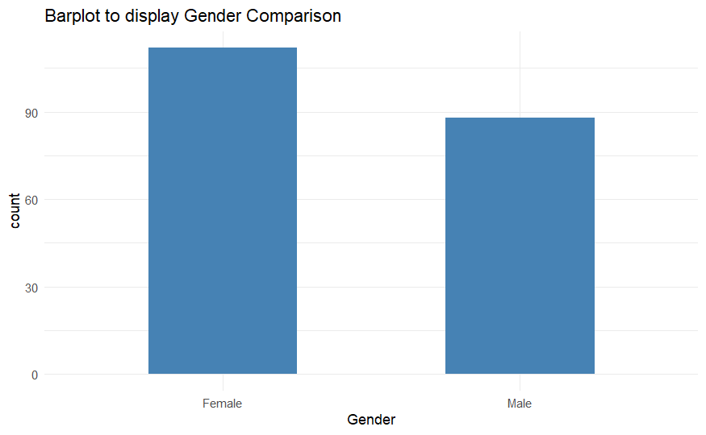

```r
# Creating a barplot to assess gender distribution of my sample of customers.
ggplot(customer_df,aes(x= Gender)) +
  geom_bar(stat="count",width=0.5,fill="steelblue") +
  theme_minimal()+
  labs(title="Barplot to display Gender Comparison", xlab="Gender")
```

From the bar chart, we can see that females are in the lead with a share around 56% whereas the males have a share around 44%.

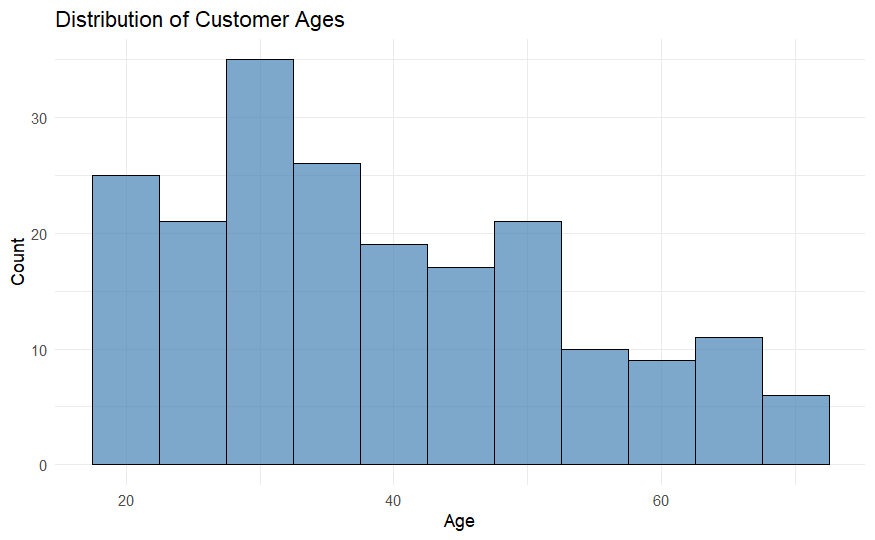

```r
# Age distribution of the customers
ggplot(customer_df, aes(x = Age)) +
  geom_histogram(binwidth = 5, fill = "steelblue", color = "black", alpha = 0.7) +
  labs(title = "Distribution of Customer Ages",
       x = "Age",
       y = "Count") +
  theme_minimal()
```

Looking at the age of customers, one can see that the biggest group is people from 20 to 35 years old (more than 35 members). The distribution of this variable is skewed to the right, so there is far more people on the left hand-side (40 years old or younger) than on the right-hand side.

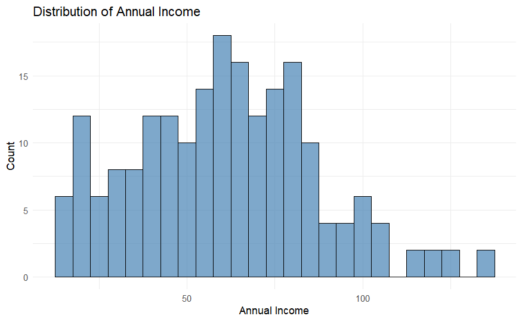

```r
# Annual income distribution of the customers
ggplot(customer_df, aes(x = Annual_Income)) +
  geom_histogram(binwidth = 5, fill = "steelblue", color = "black", alpha = 0.7) +
  labs(title = "Distribution of Annual Income",
       x = "Annual Income",
       y = "Count") +
  theme_minimal()
```

There is a lot of customers that earn up to 80 thousands annually. Earnings greater than this amount are far less popular than smaller incomes.

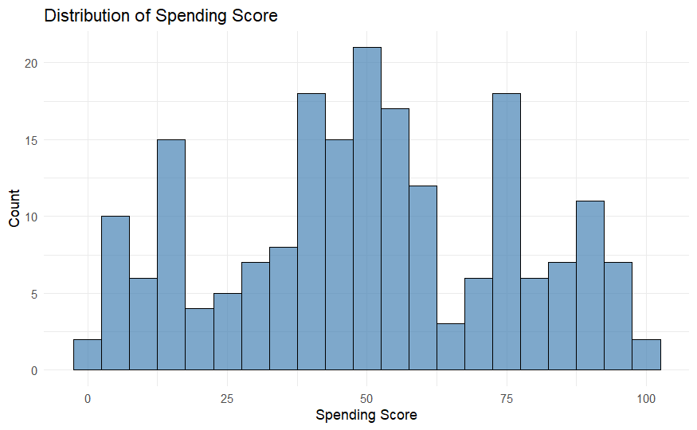

```r
# Annual income distribution of the customers
ggplot(customer_df, aes(x = Spending_Score)) +
  geom_histogram(binwidth = 5, fill = "steelblue", color = "black", alpha = 0.7) +
  labs(title = "Distribution of Spending Score",
       x = "Spending Score",
       y = "Count") +
  theme_minimal()
```

The spending score of customers resembles a bit of the normal distribution. Most of the observations are concentrated around the mean (50) and both sides of the graph look very similar. There are many observations at both ends, meaning that there is a quite a lot of customers who spend very little or very much.

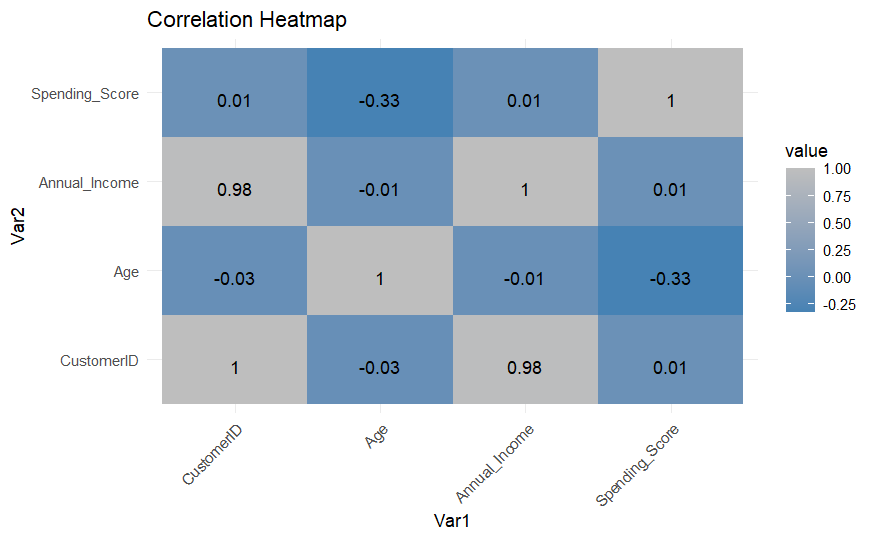

```r
# Calculate the correlation matrix
numeric_customer_df <- customer_df[, sapply(customer_df, is.numeric)]
corr_matrix <- cor(numeric_customer_df)

# Heatmap
ggplot(data = melt(corr_matrix), aes(Var1, Var2, fill = value)) +
  geom_tile() +
  geom_text(aes(label = round(value, 2)), vjust = 1) +  # Add labels with 2 decimal places
  scale_fill_gradient(low = "steelblue", high = "gray") +
  theme_minimal() +
  theme(axis.text.x = element_text(angle = 45, hjust = 1)) +
  labs(title = "Correlation Heatmap")
```

The heat map shows the correlation of the variables. There seems to be a positive correlation between the custmerID and the Annual_Income.

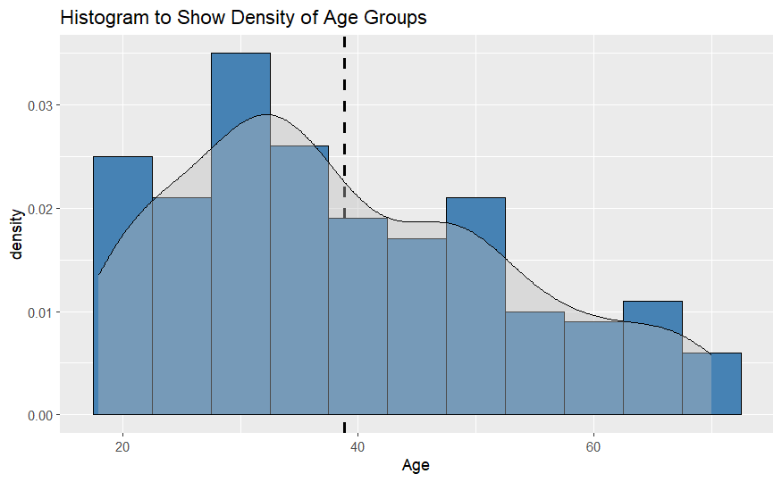

```r
# Histogram to show dispersion of mall customers based on age groups
ggplot(customer_df, aes(x = Age)) +
  geom_vline(aes(xintercept = mean(Age)), color = "black",  #adding an intercept to indicate mean age
             linetype = "dashed", size = 1.0) +
  geom_histogram(binwidth = 5, aes(y = ..density..),
                 color = "black", fill = "steelblue") +
  geom_density(alpha = 0.4, fill = "gray") +  #adding density plot
  labs(title = "Histogram to Show Density of Age Groups")
```

The distribution of this variable is skewed to the right, so there is far more people on the left hand-side (40 years old or younger) than on the right-hand side.

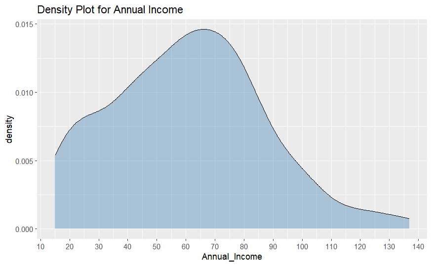

```r
# Creating density plot to show customer's annual income
ggplot(customer_df, aes(x = Annual_Income)) +
  geom_density(alpha=0.4, fill="steelblue") +
  scale_x_continuous(breaks = seq(0, 200, by = 10)) +
  labs(title="Density Plot for Annual Income")
```

The distribution of this variable is skewed to the right, with lot of customers that earn up to 80 thousands annually.

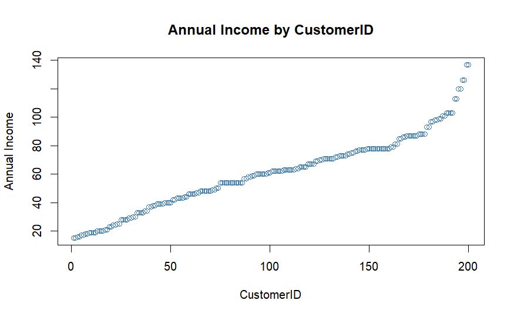

```r
# Assuming 'data' is your data frame
plot(customer_df$CustomerID, customer_df$Annual_Income,
     type = "p",
     col = "steelblue",
     main = "Annual Income by CustomerID",
     xlab = "CustomerID",
     ylab = "Annual Income"
)
```

The is a linear correlation in the arrangement of the CustomerID and their Annual_Income.

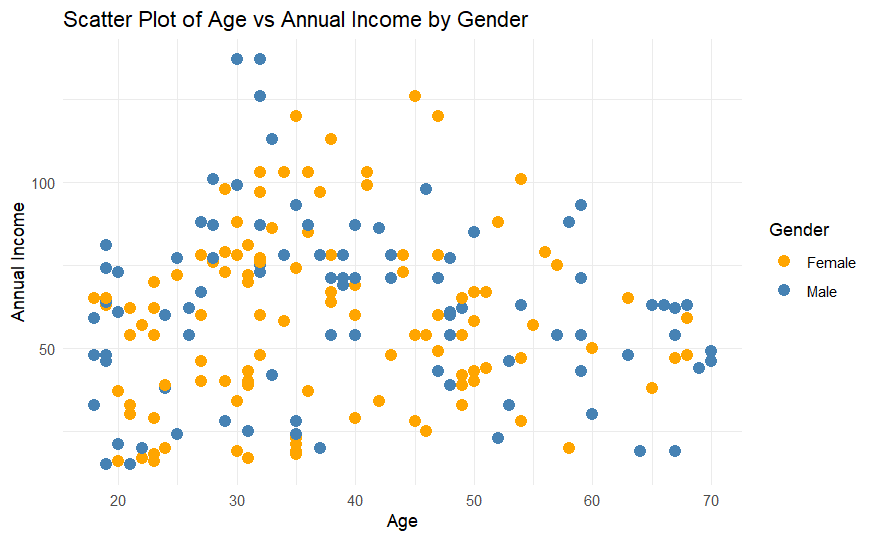

```r
# Assuming 'customer_df' is your data frame
ggplot(customer_df, aes(x = Age, y = Annual_Income, color = Gender)) +
  geom_point(size = 3) +
  labs(title = "Scatter Plot of Age vs Annual Income by Gender",
       x = "Age",
       y = "Annual Income") +
  scale_color_manual(values = c("orange","steelblue")) +
  theme_minimal()
```

From the scatter plot, we can conclude that the highest income can be observed for people with age from 28 to 48.

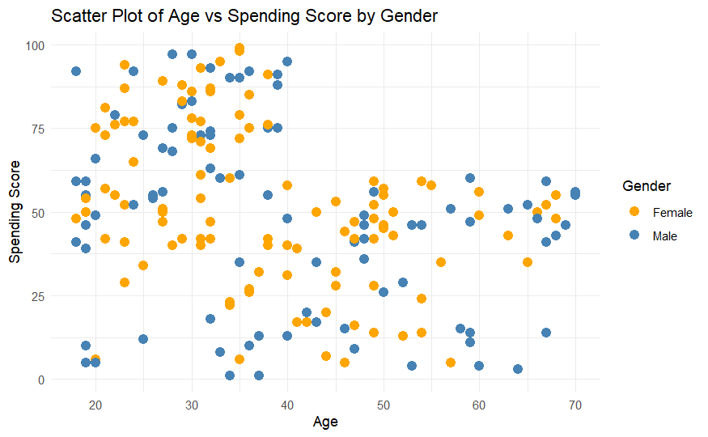

```r
# Assuming 'customer_df' is your data frame
ggplot(customer_df, aes(x = Age, y = Spending_Score, color = Gender)) +
  geom_point(size = 3) +
  labs(title = "Scatter Plot of Age vs Spending Score by Gender",
       x = "Age",
       y = "Spending Score") +
  scale_color_manual(values = c("orange","steelblue")) +
  theme_minimal()
```

The above plot, we can see that all the ‘big spenders’ are not more than 40 years old. Customers above that age, tend to be more frugal as the highest values of Spending Score are around 60 points.

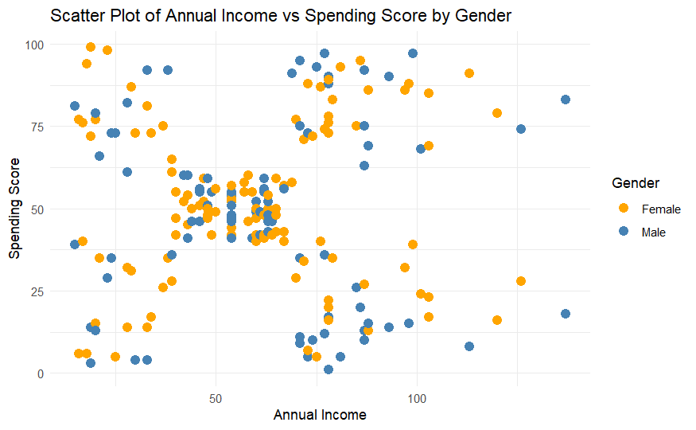

```r
# Assuming 'customer_df' is your data frame
ggplot(customer_df, aes(y = Spending_Score, x = Annual_Income, color = Gender)) +
  geom_point(size = 3) +
  labs(title = "Scatter Plot of Annual Income vs Spending Score by Gender",
       y = "Spending Score",
       x = "Annual Income") +
  scale_color_manual(values = c("orange","steelblue")) +
  theme_minimal()
```

We can see that observations tend to group themselves in a couple of areas on the graph. There is a numerous group right in the middle and a few groups in the corners of the plot. Gender seems to have little effect when income and spending of customers is analysed.

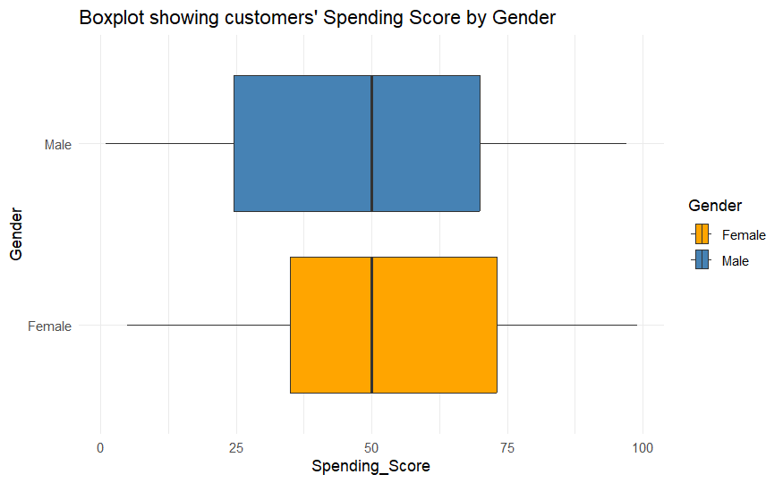

```r
# Assuming 'customer_df' is your data frame
ggplot(customer_df, aes(x = Spending_Score, y = Gender, fill = Gender)) +
  geom_boxplot() +
  labs(title = "Boxplot showing customers' Spending Score by Gender") +
  scale_fill_manual(values = c("orange","steelblue")) +
  theme_minimal()
```

From the boxplot, we can see that the median spending score for both males and females are equal. We can also see that more women have a spending score above the median (50), whereas men tend to have a spending score below the median.

## Training the Models

Clustering, a fundamental task in unsupervised learning, involves grouping data points based on similarities within the dataset. This abstract provides an overview and comparison of three prominent clustering models: K-Means Clustering, Hierarchical Clustering, and DBSCAN. K-Means partitions the dataset into distinct groups by minimizing the sum of squared distances. Hierarchical Clustering creates a tree of clusters where similar data points are merged iteratively. DBSCAN identifies clusters based on density and effectively handles outliers.

## Model Implementation Using K-Means Clustering

I’ll use k-means algorithm, a method which identifies k number of centroids (centers of a cluster) and allocates every single observation (data point) to the nearest cluster. K-Means Clustering is a fundamental unsupervised machine learning algorithm aimed at partitioning data into distinct groups based on similarities within the dataset. This abstract explores the mechanism of K-Means Clustering, its applications, strengths, and limitations. The algorithm iteratively assigns data points to clusters and adjusts cluster centroids until convergence. It relies on minimizing the sum of squared distances between data points and their respective cluster centroids.

```r
# Setting seed to 125 for reproducibility
set.seed(1)
```

It is crucial to determine the most optimal number of clusters using the variables; Age, Annual_Income and Spending_Score. In order to do so I’ll use the elbow method from the ClusterR package, which plots the explained variation as a function of the number of clusters. The ‘elbow’ of the plot should correspond to the most optimal number of clusters.

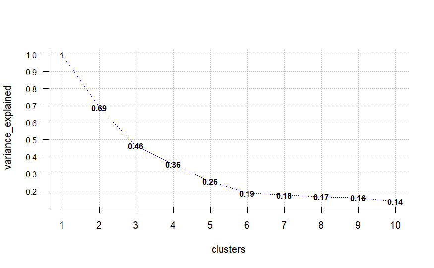

```r
# Plotting the variations of clusters
opt <- Optimal_Clusters_KMeans(customer_df[, 3:5], max_clusters = 10, plot_clusters = T)
```

From the plot above, it is quite hard to clearly define where does the ‘elbow’ occur. Let’s use another method called ‘silhouette’ to identify the number of clusters. It measures how similar is an object to its own cluster compared to other clusters. I’ll plot the average sillhoute value for k ranging from 2 to 10 and the highest value received should help us determine most optimal number of clusters.

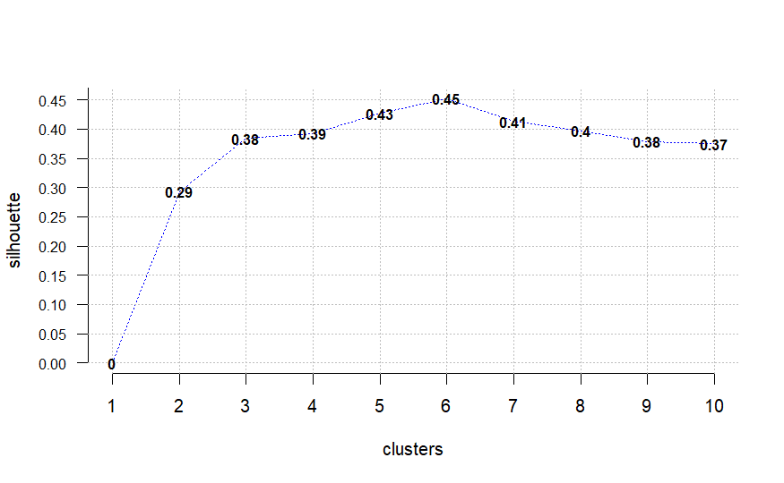

```r
# Getting the optimal clusters
opt <- Optimal_Clusters_KMeans(customer_df[, 3:5], max_clusters = 10, plot_clusters = T, criterion = 'silhouette')
```

The highest average sillhoute value (equal to 0.45) is present for k = 6. Therefore we should opt for 6 clusters in our further analysis with k-means algorithm.

Creating the k-means clustering model for the data

```r
#Creating the customer clusters with KMeans
km6<-kmeans(customer_df[,3:5], 6, iter.max = 100, nstart=50,
           algorithm = "Lloyd")
#Print the result
km6
```

```
K-means clustering with 6 clusters of sizes 45, 35, 38, 21, 39, 22

Cluster means:
       Age Annual_Income Spending_Score
1 56.15556      53.37778       49.08889
2 41.68571      88.22857       17.28571
3 27.00000      56.65789       49.13158
4 44.14286      25.14286       19.52381
5 32.69231      86.53846       82.12821
6 25.27273      25.72727       79.36364

Clustering vector:
  [1] 4 6 4 6 4 6 4 6 4 6 4 6 4 6 4 6 4 6 4 6 4 6 4 6 4 6 4 6 4 6 4 6 4 6 4 6 4 6 4 6 1 6 1 3 4 6
 [47] 1 3 3 3 1 3 3 1 1 1 1 1 3 1 1 3 1 1 1 3 1 1 3 3 1 1 1 1 1 3 1 3 3 1 1 3 1 1 3 1 1 3 3 1 1 3
 [93] 1 3 3 3 1 3 1 3 3 1 1 3 1 3 1 1 1 1 1 3 3 3 3 3 1 1 1 1 3 3 3 5 3 5 2 5 2 5 2 5 3 5 2 5 2 5
[139] 2 5 2 5 3 5 2 5 2 5 2 5 2 5 2 5 2 5 2 5 2 5 2 5 2 5 2 5 2 5 2 5 2 5 2 5 2 5 2 5 2 5 2 5 2 5
[185] 2 5 2 5 2 5 2 5 2 5 2 5 2 5 2 5

Within cluster sum of squares by cluster:
[1]  8062.133 16690.857  7742.895  7732.381 13972.359  4099.818
 (between_SS / total_SS =  81.1 %)

Available components:

[1] "cluster"      "centers"      "totss"        "withinss"     "tot.withinss" "betweenss"
[7] "size"         "iter"         "ifault"
```

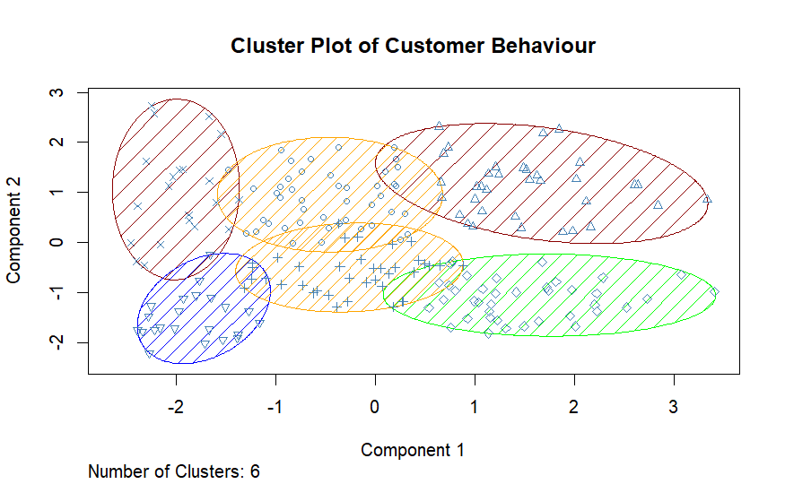

```r
# Define the clustering variable
cluster_variable <- km6$cluster

# Showing the six KMeans clusters
clusplot(
  customer_df,                    # Data frame
  cluster_variable,               # Clustering variable
  color = TRUE,                   # Use color for clusters
  shade = TRUE,                   # Use shading
  labels = 0,                     # Do not show point labels
  lines = 0,                      # Do not show lines
  main = "Cluster Plot of Customer Behaviour",  # Main title
  sub = paste("Number of Clusters:", max(cluster_variable)),  # Subtitle with the number of clusters
  col.p = "steelblue",            # Color for points
  col.clus = c("darkred", "green", "blue", "orange"),  # Colors for cluster ellipses
  cex = 0.8                       # Size of labels and points
)
```

From the clustering model, it seems that two main components can explain up to 66% of the variability in the data. The results also show more details of the cluster, including the means of the customers’ age, annual income, and spending score in each cluster.

Next, I will perform a Principal Component Analysis (PCA) to reduce the dimensionality of the data and capture the 2 most significant components of the data

```r
#Perform Principal Component Analysis
pcclust<-prcomp(customer_df[, 3:5], scale=FALSE)

#Checking the summary of the PCA model
summary(pcclust)
```

```
Importance of components:
                           PC1     PC2     PC3
Standard deviation     26.4625 26.1597 12.9317
Proportion of Variance  0.4512  0.4410  0.1078
Cumulative Proportion   0.4512  0.8922  1.0000
```

```r
# Applying the PCA model on the data
pcclust$rotation[, 1:2]
```

```
                      PC1        PC2
Age             0.1889742 -0.1309652
Annual_Income  -0.5886410 -0.8083757
Spending_Score -0.7859965  0.5739136
```

Results from the PCA show that components 1 and 2 (PC1 and PC2) contribute the most variance to the data. The high correlation between PC1 and spending score (-0.786) and PC2 and annual income (-0.808) show that annual income and spending score are the 2 major components of the data.

Finally, I will plot the customer segments based on results from the cluster analysis and PCA.

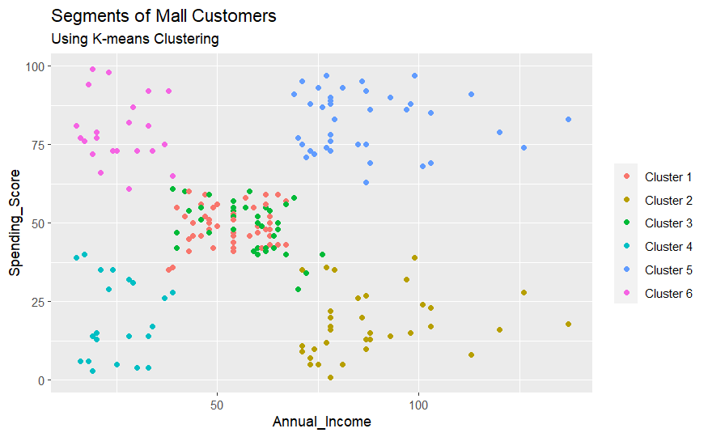

```r
# A plot of the customers segments

ggplot(customer_df, aes(x = Annual_Income , y = Spending_Score)) +
  geom_point(stat = "identity", aes(color = as.factor(km6$cluster))) +
  scale_color_discrete(name = " ",
                       breaks=c("1", "2", "3", "4", "5","6"),
                       labels=c("Cluster 1", "Cluster 2", "Cluster 3",
                                "Cluster 4", "Cluster 5","Cluster 6")) +
  ggtitle("Segments of Mall Customers",
          subtitle = "Using K-means Clustering")
```

Based on the plot, we can easily classify each cluster by annual income and spending score and make it more readable.

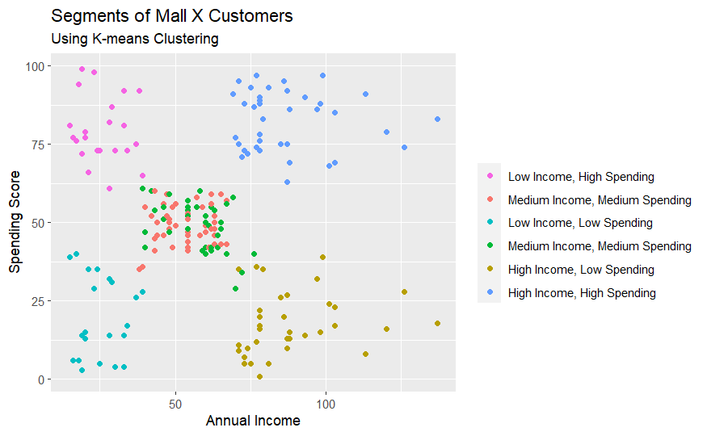

```r
# A plot of the customers segments
ggplot(customer_df, aes(x = Annual_Income , y = Spending_Score)) +
  geom_point(stat = "identity", aes(color = as.factor(km6$cluster))) +
  scale_color_discrete(name = " ",
                       breaks=c( "6", "1", "4", "3", "2","5"),
                       labels=c("Low Income, High Spending", "Medium Income, Medium Spending", "Low Income, Low Spending",
                                "Medium Income, Medium Spending","High Income, Low Spending", "High Income, High Spending")) +
  labs(x="Annual Income", y="Spending Score") +
  ggtitle("Segments of Mall X Customers",
          subtitle = "Using K-means Clustering")
```

## Model Implementation Using DBSCAN clustering

I will be using the DBSCAN to detect the presence of noise and outliers in the data. Density-Based Spatial Clustering of Applications with Noise (DBSCAN) is an unsupervised clustering algorithm used to identify clusters within datasets, particularly effective in handling noise and outliers.

First we normalize the important columns.

```r
# Extracting the columns to be standardized
columns_to_standardize <- c("Age", "Annual_Income", "Spending_Score")
customer_df_scaled <- customer_df

# Standardizing the selected columns in the dataframe
customer_df_scaled[, columns_to_standardize] <- scale(customer_df[, columns_to_standardize])
```

```r
# Run DBSCAN
dbscan_result <- dbscan(customer_df_scaled[, c("Age", "Annual_Income", "Spending_Score")], eps = 0.5, minPts = 5)
```

```r
# Access cluster assignments and noise points
clusters <- dbscan_result$cluster
noise_points <- dbscan_result$cluster == 0  # Noise points will have cluster ID 0
```

```r
# Convert to a data frame for ggplot
customer_df_scaled$Cluster <- as.factor(clusters)
```

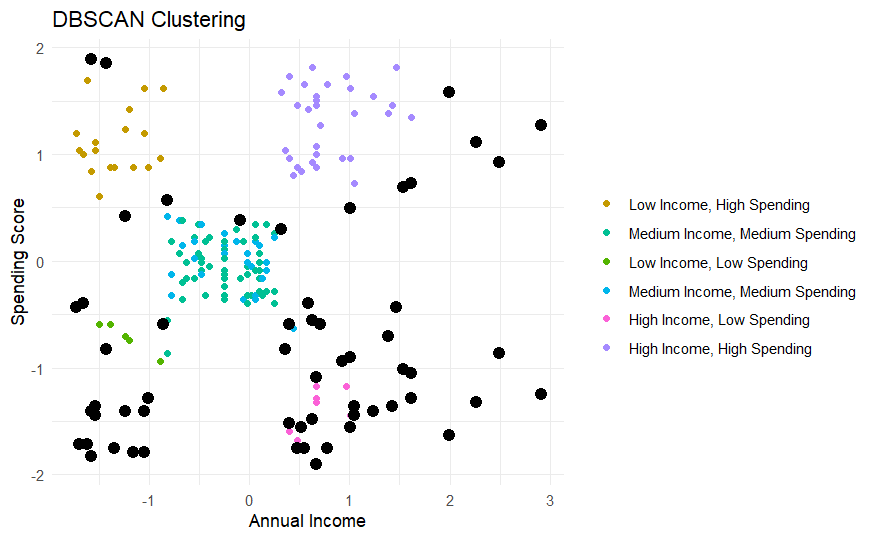

```r
# Visualize clusters and noise points using ggplot
ggplot(customer_df_scaled, aes(x = Annual_Income, y = Spending_Score, color = Cluster)) +
  geom_point() +
  geom_point(data = subset(customer_df_scaled, noise_points), color = "black", size = 3) +
  labs(x = "Annual Income", y = "Spending Score", title = "DBSCAN Clustering") +
  scale_color_discrete(name = " ",
                       breaks=c("1", "3", "2", "4", "6","5"),
                       labels=c("Low Income, High Spending", "Medium Income, Medium Spending", "Low Income, Low Spending",
                                "Medium Income, Medium Spending","High Income, Low Spending", "High Income, High Spending")) +
  theme_minimal()
```

```r
NA
NA
```

From the DBSCAN plot above, we can notice the presence of noisy data and outliers which are the black dots.

```r
# Summary of clusters
summary(clusters)
```

```
   Min. 1st Qu.  Median    Mean 3rd Qu.    Max.
  0.000   0.000   3.000   2.475   4.000   6.000
```

```r
# Summary of noise points
summary(noise_points)
```

```
   Mode   FALSE    TRUE
logical     141      59
```

The noisy data and outliers are close to 30% of the data.

## Model Implementation Using Hierarchical clustering

Hierarchical Clustering is an unsupervised machine learning technique that organizes data into a nested hierarchy of clusters. This method doesn’t require the number of clusters to be predefined, allowing for a versatile approach to grouping data points based on their similarity. The mechanism of Hierarchical Clustering involves building a dendrogram, a tree-like structure illustrating the arrangement of clusters.

I will use agglomerative hierarchical clustering (also known as bottom-up approach), a method used o group objects based on their similarity. At the beginning each observation starts in its own cluster, and step by step pairs of clusters are merged as we move up the hierarchy. Before I implement the clustering algorithm, I will compare the distances between the data points and in the next step the ‘hclust’ function will be used to perform the cluster analysis.

```r
# Comparing the distances between the data points using ‘hclust’ function
dist_customers <- dist(customer_df[,3:5])
hc_customers <- hclust(dist_customers, method = 'complete')
```

```r
# Choosing the optimal cluster
for(i in 2:7) {
  nam <- paste("clust", i, sep = "")
  assign(nam, cutree(hc_customers, k = i))
}

par(mfrow = c(3, 2))

plot(silhouette(clust2, dist_customers), col = "blue")
plot(silhouette(clust3, dist_customers), col = 'blue')
```

```r
plot(silhouette(clust4, dist_customers), col = "blue")
plot(silhouette(clust5, dist_customers), col = "blue")
```

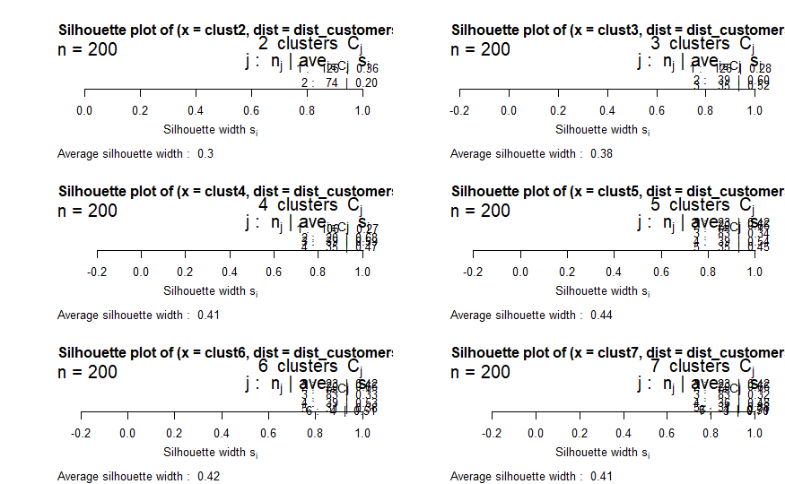

```r
plot(silhouette(clust6, dist_customers), col = "blue")
plot(silhouette(clust7, dist_customers), col = "blue")
```

```r
NA
NA
```

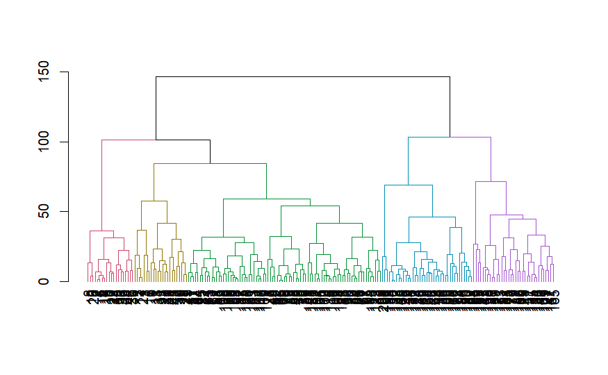

```r
# plot the dendrogram.
clust_customers <- cutree(hc_customers, k = 5)
dend_customers <- as.dendrogram(hc_customers)
dend_colored <- color_branches(dend_customers, k = 5)
par(mfrow = c(1, 1))
plot(dend_colored)
```

```r
# Extract the clusters
km <- kmeans(customer_df[,3:4], 5)
customer_df_km$ClusterNumber <- km$cluster
segment_customers <- mutate(customer_df_km, cluster = clust_customers)
segment_customers = subset(segment_customers, select = -c(ClusterNumber))
```

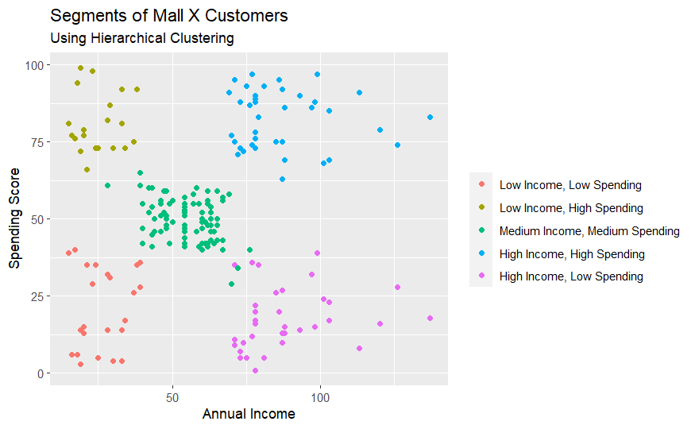

```r
#Create a plot of the customers segments
ggplot(segment_customers, aes(x = Annual_Income, y = Spending_Score, color = factor(cluster))) +
  geom_point() +
  scale_color_discrete(name = " ",
                       breaks=c("1", "2", "3", "4", "5"),
                       labels=c("Low Income, Low Spending","Low Income, High Spending", "Medium Income, Medium Spending","High Income, High Spending",
                                "High Income, Low Spending")) +
  labs(x="Annual Income", y="Spending Score") +
  ggtitle("Segments of Mall X Customers",
          subtitle = "Using Hierarchical Clustering")
```

Presented graph is very alike to the one we obtained with k-means clustering. Except couple of observations that are now in the group with medium spending score and annual income, all the other ones are in the same groups as in previous clustering. Finally, we can find out what characteristcs each of the groups have by exploring the ‘segment_customers’ dataframe.

```r
# Getting the characteristcs each of the groups
segment_customers %>% group_by(cluster, Gender) %>%
  summarise_all(list(mean)) %>% arrange(cluster)
```

| cluster | Gender | CustomerID | Age | Annual_Income | Spending_Score |
| --- | --- | --- | --- | --- | --- |
| 1 | Female | 24.71429 | 43.21429 | 27.35714 | 21.71429 |
| 1 | Male | 20.33333 | 48.33333 | 24.66667 | 19.66667 |
| 2 | Female | 20.83333 | 25.58333 | 24.58333 | 81.83333 |
| 2 | Male | 23.00000 | 23.75000 | 25.50000 | 79.75000 |
| 3 | Female | 86.72000 | 40.20000 | 55.32000 | 48.92000 |
| 3 | Male | 82.66667 | 45.12121 | 53.90909 | 51.06061 |
| 4 | Female | 163.33333 | 32.19048 | 86.04762 | 81.66667 |
| 4 | Male | 160.44444 | 33.27778 | 87.11111 | 82.66667 |
| 5 | Female | 171.00000 | 44.60000 | 92.33333 | 21.60000 |
| 5 | Male | 159.50000 | 39.50000 | 85.15000 | 14.05000 |

```r
NA
```

In the first cluster we have middle aged women and men, whose both annual income and spending scores are small. In the second group we have young women and men, who despite the fact they don’t have much income, tend to spend a lot. The third group is the most numerous one, which was right in the middle of the presented plots. This cluster constitues of female and male in their forties, which get a middle-sized wages and have moderate spending habits. In group number 4, there are mostly people in their early 30s who earn a lot and also tend to spend much. In the last cluster (number 5), we can see women whose average age was around 44 years old and men with average age circa 39 years old. This group of people, similarly to those in group number 4, have high annual incomes, but on the contrary, they do not like to spend much.